# V. Applied Statistics in R (presentation)

Center for Health Data Science, University of Copenhagen

07 October, 2022

## Structure of a biostatistical analysis in R

The very basic structure of an R script doing a classical statistical analysis is as follows:

- Load packages that you will be using.
- Read the dataset to be analyzed. Possibly also do some data cleaning and manipulation.
- Visualize the dataset by graphics and other descriptive statistics.
- Fit and validate a statistical model.
- Hypothesis testing. Possibly also post hoc testing.

Of course there are variants of this set-up, and in practice there will often be some iterations of the steps.  
In this manuscript we will exemplify the proposed steps in the analysis of a simple dataset:

- In our current scenario, you are a researcher investigating psoriasis, an inflammatory skin disease. You have data on the expression of a number genes that are suspected to have something to do with the disease, but you cannot be sure until you perform some formal statistical analysis.
- This is a great example where R skills would come very handy!
- You will investigate your gene of special interest GeneD (a hypothetical gene in this case).
- You decide that your analysis approach will be one-way ANOVA of the expression of GeneD against the skin type in psoriasis patients.

#### Load packages

We will use **ggplot2** to make plots, and to be prepared for data manipulations, we simply load this together with the rest of the **tidyverse**.

The psoriasis data are provided in an Excel sheet, so we also load **readxl**. Finally, we will use the package **emmeans** to make post hoc tests.

Remember that you should install the wanted packages before they can be used (but you only need to install the packages once!).

Thus,

```r
#install.packages("tidyverse")
#install.packages("readxl")
#install.packages("emmeans")
library(tidyverse)
library(readxl)
library(emmeans)
```

Now, we are done preparing for our analyses. Next, we will look specifically at the possible association between GeneD expression and psoriasis. Finally, we conclude with a brief outlook on other statistical models in R.

## Example: Analysis of variance

#### Step 1: Data

The data are saved in the file **psoriasis.xlsx**. At first the variable `type` is stored as a character variable, we change it to a factor (and check that indeed there are 15, 15 and 7 patients in the three groups).

```r
psoriasisData <- read_excel("./data/psoriasis.xlsx")

# Dataset1
psorData  <- select(psoriasisData, type, GeneD)

# Dataset2
psorDataG <- select(psoriasisData, -GeneD)


psorData <- mutate(psorData, type = factor(type))
count(psorData, type)
```

```
## # A tibble: 3 x 2
##   type        n
##   <fct>   <int>
## 1 healthy     7
## 2 psne       15
## 3 psor       15
```

#### Step 2: Descriptive plots and statistics

To get an impression of the data, we make two plots and compute group-wise means and standard deviations.

```
## # A tibble: 3 x 4
##   type        avg  median    sd
##   <fct>     <dbl>   <dbl> <dbl>
## 1 healthy  0.557   0.590  0.121
## 2 psne    -0.0292 -0.0331 0.197
## 3 psor     1.03    1.04   0.171
```

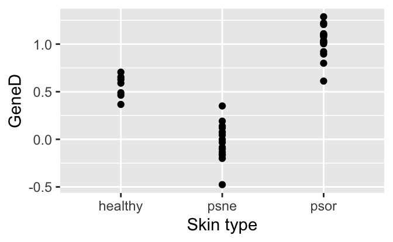

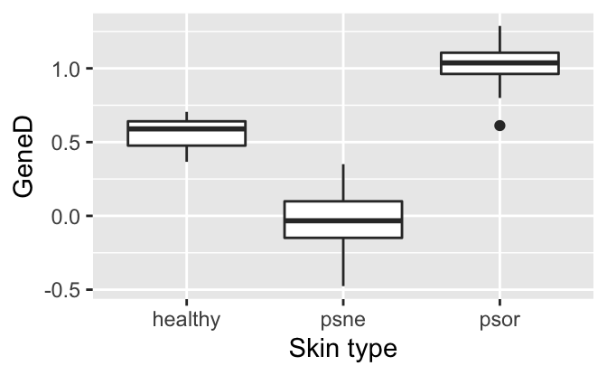

```r
ggplot(psorData, aes(x=type, y=GeneD)) +
  geom_point() +
  labs(x="Skin type", y="GeneD")

ggplot(psorData, aes(x=type, y=GeneD)) +
  geom_boxplot() +
  labs(x="Skin type", y="GeneD")

psorData %>%
  group_by(type) %>%
  summarise(avg=mean(GeneD), median=median(GeneD), sd=sd(GeneD))
```

#### Step 3: Fit of oneway ANOVA, model validation

The scientific question is whether the gene expression level of GeneD differs between the three types/groups. Thus, the natural type of analysis is a oneway analysis of variance (ANOVA). The oneway ANOVA is fitted with a function in R. It is a good approach to assign a name (below *oneway*) to the object with the fitted model. This object contains all relevant information and may be used for subsequent analysis. Note that we need to logarithmic transform the response as intensities are often on a multiplicative scale.

```r
oneway <- lm(log(GeneD) ~ type, data=psorData)
oneway
```

```
##
## Call:
## lm(formula = log(GeneD) ~ type, data = psorData)
##
## Coefficients:
## (Intercept)     typepsne     typepsor
##     -0.6079      -1.4693       0.6198
```

#### Step 4: Hypothesis test + Post hoc tests

```r
drop1(oneway,test="F")
```

```
## Single term deletions
##
## Model:
## log(GeneD) ~ type
##        Df Sum of Sq    RSS     AIC F value    Pr(>F)
## <none>               3.345 -53.492
## type    2    18.707 22.052  -4.686  69.907 5.779e-11 ***
## ---
## Signif. codes:  0 '***' 0.001 '**' 0.01 '*' 0.05 '.' 0.1 ' ' 1
```

```r
emmeans(oneway,~type)
```

```
##  type     emmean     SE df lower.CL upper.CL
##  healthy -0.6079 0.1383 25   -0.893   -0.323
##  psne    -2.0772 0.1493 25   -2.385   -1.770
##  psor     0.0119 0.0944 25   -0.183    0.206
##
## Results are given on the log (not the response) scale.
## Confidence level used: 0.95
```

```r
pairs(emmeans(oneway,~type))
```

```
##  contrast       estimate    SE df t.ratio p.value
##  healthy - psne     1.47 0.204 25   7.220 <.0001
##  healthy - psor    -0.62 0.167 25  -3.702 0.0029
##  psne - psor       -2.09 0.177 25 -11.823 <.0001
##
## Results are given on the log (not the response) scale.
## P value adjustment: tukey method for comparing a family of 3 estimates
```

## Outlook: Other analyses

The `lm` function is used for linear models, that is, models where data points are assumed to be independent with a Gaussian (i.e. normal) distribution (and typically also with the same variance). Obviously, these models are not always appropriate, and there exists functions for many, many more situations and data types. Here, we just mention a few functions corresponding to common data types and statistical problems.

- `glm`: For independent, but non-Gaussian data. Examples are binary outcomes (logistic regression) and outcomes that are counts (Poisson regression). glm is short for generalized linear models, and the `glm` function is part of the base installation of R.
- `lmer` and `glmer`: For data with dependence structures that can be described by random effects, e.g., block designs. lme is short for linear mixed effects (Gaussian data), glmer is short for generalized linear mixed effects (binary or count data). Both functions are part of the **lme4** package.
- `nls`: For non-linear regression, e.g., dose-response analysis. nls is short for non-linear least squares. The function is included in the base installation of R.

The functions mentioned above are used in a similar way as `lm`: a model is fitted with the function in question, and the model object subsequently examined with respect to model validation, estimation, computation of confidence limits, hypothesis tests, prediction, etc. with functions `summary`, `confint`, `drop1`, `emmeans`, `pairs` as indicated above.